```python
import warnings
warnings.filterwarnings("ignore", category=FutureWarning)
import pandas as pd
import seaborn as sns
import matplotlib.pyplot as plt
import statsmodels.api as sm
from sklearn.preprocessing import LabelEncoder
plt.rcParams["figure.figsize"] = (15, 25)
plt.rcParams["xtick.labelsize"] = 16
plt.rcParams["ytick.labelsize"] = 16
plt.rcParams["axes.labelsize"] = 20
plt.rcParams['legend.fontsize'] = 20
%matplotlib inline
```

# Question 1

```python
data = pd.read_csv("3-Year_Recidivism_for_Offenders_Released_from_Prison.csv")
data.head()
```

|  | Fiscal Year Released | Recidivism Reporting Year | Race - Ethnicity | Sex | Age At Release | Convicting Offense Classification | Convicting Offense Type | Convicting Offense Subtype | Release Type | Main Supervising District | Recidivism - Return to Prison | Recidivism Type | Days to Recidivism | New Conviction Offense Classification | New Conviction Offense Type | New Conviction Offense Sub Type | Part of Target Population |
| --- | --- | --- | --- | --- | --- | --- | --- | --- | --- | --- | --- | --- | --- | --- | --- | --- | --- |
| 0 | 2010 | 2013 | White - Non-Hispanic | M | Under 25 | D Felony | Violent | Assault | Parole | 4JD | Yes | Tech | 16.0 | NaN | NaN | NaN | Yes |
| 1 | 2010 | 2013 | White - Non-Hispanic | M | 55 and Older | D Felony | Public Order | OWI | Parole | 7JD | Yes | Tech | 19.0 | NaN | NaN | NaN | Yes |
| 2 | 2010 | 2013 | White - Non-Hispanic | M | 25-34 | D Felony | Property | Burglary | Parole | 5JD | Yes | Tech | 22.0 | NaN | NaN | NaN | Yes |
| 3 | 2010 | 2013 | White - Non-Hispanic | M | 55 and Older | C Felony | Drug | Trafficking | Parole | 8JD | Yes | Tech | 25.0 | NaN | NaN | NaN | Yes |
| 4 | 2010 | 2013 | Black - Non-Hispanic | M | 25-34 | D Felony | Drug | Trafficking | Parole | 3JD | Yes | Tech | 26.0 | NaN | NaN | NaN | Yes |

```python
encoder = LabelEncoder()
data['Y'] = encoder.fit_transform(data['Recidivism - Return to Prison'])
data['D'] = encoder.fit_transform(data['Part of Target Population'])
data[['Recidivism - Return to Prison', 'Y', 'Part of Target Population', 'D']].tail()
```

|  | Recidivism - Return to Prison | Y | Part of Target Population | D |
| --- | --- | --- | --- | --- |
| 21641 | No | 0 | Yes | 1 |
| 21642 | Yes | 1 | Yes | 1 |
| 21643 | No | 0 | No | 0 |
| 21644 | No | 0 | No | 0 |
| 21645 | Yes | 1 | Yes | 1 |

# Question 2

```python
data.groupby('D').count()['Y'].reset_index().set_index("D")
```

| D | Y |
| --- | --- |
| 0 | 10178 |
| 1 | 11468 |

$Pr(Participant) = Pr(D = 1) = \frac{11468}{21646} = 0.5297976531460779$

$Pr(Not Participant) = Pr(D = 0) = 1 - Pr(D = 1) = 0.47020234685392215$

```python
data.groupby('Y').count()['D'].reset_index().set_index("Y")
```

| Y | D |
| --- | --- |
| 0 | 14619 |
| 1 | 7027 |

$E(Recidivist) = Pr(Recidivist) = Pr(Y = 1) = \frac{7027}{21646} = 0.32463272660075765$

```python
subset = data[['Y','D']]
subset[subset['D'] == 1].groupby('Y').count()
```

| Y | D |
| --- | --- |
| 0 | 7131 |
| 1 | 4337 |

```python
subset = data[['Y','D']]
subset[subset['D'] == 0].groupby('Y').count()
```

| Y | D |
| --- | --- |
| 0 | 7488 |
| 1 | 2690 |

$\frac{7488}{10178} = 0.7357044606012969$

$\frac{2690}{10178} = 0.2642955393987031$

$$E[Recidivist | Not Participant] = E[Y | D = 0] = 0 \cdot 0.7357044606012969 + 1 \cdot 0.2642955393987031 = 0.2642955393987031$$

```python
data.shape[0]
```

```
21646
```

$N = 21646$

# Question 3

$\hat{\Delta}^{ATE}_{N} = 0.37798500958689213 - 0.2642955393987031 = 0.11368947018818903$

# Question 4

This suggests that participating in the program causes recidivism!

The underlying assumptions are:

- $E(Y_{1i}) = E[Y_{1i}|D=1]$
- $E(Y_{0i}) = E[Y_{0i}|D=0]$

# Question 5

Let's bound the impacts:

$E(Y_{1i}) = Pr(D=1) \cdot E[Y_{1i}|D=1] + Pr(D=0) \cdot E[Y_{1i}|D=0]$

The missing counter factual is: $E[Y_{1i}|D=0]$

This term represents: The expected value of those who were treatment (in reality) had they not been treated.

In simple terms: What would have happened to the people who were treated had they not been treated.

This is something that we cannot observe - hence, it is the missing counterfactual.

# Question 6

$E(Y_{1i})^{UB} = 0.5297976531460779 \cdot 0.37798500958689213 + 0.47020234685392215 \cdot 1 = 0.6704579178574553$

$E(Y_{1i})^{LB} = 0.5297976531460779 \cdot 0.37798500958689213 + 0.47020234685392215 \cdot 0 = 0.2002555710035332$

# Question 7

$E(Y_{1i}) = Pr(D=1) \cdot E[Y_{0i}|D=1] + Pr(D=0) \cdot E[Y_{0i}|D=0]$

The missing counter factual is: $E[Y_{0i}|D=1]$

This term represents: The expected value of those who did not recieve treatment (in reality) had they been treated.

In other words, what would have happened to those who were not treated, had they been treated - this is something we cannot observe, hence it is the counter factual!

# Question 8

$E(Y_{0i})^{UB} = 0.5297976531460779 \cdot 1 + 0.47020234685392215 \cdot 0.2642955393987031 = 0.6540700360343713$

$E(Y_{0i})^{LB} = 0.5297976531460779 \cdot 0 + 0.47020234685392215 \cdot 0.2642955393987031 = 0.12427238288829344$

# Question 9

$ATE^{UB} = E(Y_{1i})^{UB} - E(Y_{0i})^{LB} = 0.6704579178574553 - 0.12427238288829344 = 0.5461855349691619$

$ATE^{LB} = E(Y_{1i})^{LB} - E(Y_{0i})^{UB} = 0.2002555710035332 - 0.6540700360343713 = -0.4538144650308381$

The bound is $(-0.454, 0.546)$

The naive estimator is within this range

```python
bounds = list(np.arange(-0.454, 0.546, 0.001))
bounds = [round(i, 3) for i in bounds]
0.114 in bounds
```

```
True
```

The no-assumptions bound, $(-0.454, 0.546)$, tells us that without assumptions the data is just not very informative - the treatment effect could reduce recidivism by about 50% or increase it by about 50%.

Manski bounds make no assumptions about the counter-factual probabilities.

A downside of bounding, at least in this manner, is that the interval is so large that it is essentially useless.

# Part II

```python
data = pd.read_stata("ENIGH.dta")
data.head()
```

|  | household_id | job_earnings | head_gender | head_age | head_schooling | tot_members | men | women | age12_64 | workers | loc_size |
| --- | --- | --- | --- | --- | --- | --- | --- | --- | --- | --- | --- |
| 0 | 100003801.0 | 100696.703125 | 1 | 33 | 10 | 2 | 1 | 1 | 2 | 2 | 1 |
| 1 | 100003802.0 | 144157.156250 | 1 | 29 | 10 | 2 | 1 | 1 | 2 | 2 | 1 |
| 2 | 100003803.0 | 82622.953125 | 1 | 47 | 10 | 6 | 2 | 4 | 3 | 1 | 1 |
| 3 | 100003804.0 | 34672.109375 | 2 | 29 | 11 | 3 | 0 | 3 | 3 | 2 | 1 |
| 4 | 100003805.0 | 42295.070312 | 1 | 55 | 10 | 2 | 2 | 0 | 2 | 1 | 1 |

# Question 1

```python
data["head_male"] = data["head_gender"].apply(lambda x: 1 if x == 1 else 0)
data[["head_gender", "head_male"]].head()
```

|  | head_gender | head_male |
| --- | --- | --- |
| 0 | 1 | 1 |
| 1 | 1 | 1 |
| 2 | 1 | 1 |
| 3 | 2 | 0 |
| 4 | 1 | 1 |

### a.

```python
data['head_male'].value_counts()/data.shape[0]
```

```
1    0.738405
0    0.261595
Name: head_male, dtype: float64
```

73.8% of households with a male head and 26.2% with female head

### b.

$Pr(Male\ Head) = 0.738$

$Pr(Not\ Male \ Head) = 0.262$

$E(Job \ Earnings) = \$23,115.943359375$

$E(Job \ Earnings \ | \ Male \ Head) = \$24,621.771484375$

$E(Job \ Earnings \ | \ Not\ Male \ Head) = \$18,864.951171875$

$N = 70,311$

Naive Estimate is $\$5,756.82$

```python
# Number of rows
data.shape[0]
```

```
70311
```

```python
#Mean Job Earnings
data['job_earnings'].mean()
```

```
23115.943359375
```

```python
#Mean Job Earnings of Male Headed Households only
data[data['head_male'] == 1]['job_earnings'].mean()
```

```
24621.771484375
```

```python
#Mean Job Earnings of Female Headed Households only
data[data['head_male'] == 0]['job_earnings'].mean()
```

```
18864.951171875
```

```python
naive_estimate = 24621.771484375 - 18864.951171875
naive_estimate
```

```
5756.8203125
```

```python
# Regress job_earnings on all features
treatment = data['head_male'].values
X = sm.add_constant(treatment)
y = data['job_earnings'].values

model = sm.OLS(y, X)
results = model.fit()
print(results.summary())
```

```
                            OLS Regression Results
==============================================================================
Dep. Variable:                      y   R-squared:                       0.006
Model:                            OLS   Adj. R-squared:                  0.006
Method:                 Least Squares   F-statistic:                     412.3
Date:                Wed, 24 Jan 2018   Prob (F-statistic):           2.12e-91
Time:                        16:05:27   Log-Likelihood:            -8.3139e+05
No. Observations:               70311   AIC:                         1.663e+06
Df Residuals:                   70309   BIC:                         1.663e+06
Df Model:                           1
Covariance Type:            nonrobust
==============================================================================
                 coef    std err          t      P>|t|      [0.025      0.975]
------------------------------------------------------------------------------
const       1.886e+04    243.623     77.435      0.000    1.84e+04    1.93e+04
x1          5756.7569    283.511     20.305      0.000    5201.075    6312.439
==============================================================================
Omnibus:                   128580.377   Durbin-Watson:                   1.668
Prob(Omnibus):                  0.000   Jarque-Bera (JB):       1104979903.554
Skew:                          12.844   Prob(JB):                         0.00
Kurtosis:                     616.608   Cond. No.                         3.68
==============================================================================

Warnings:
[1] Standard Errors assume that the covariance matrix of the errors is correctly specified.
```

```python
treatment_coef = results.params[-1]
treatment_coef
```

```
5756.7568505249183
```

The naive estimate and the bivariate regression are in agreement - this is expected.

We can interpret this result as: Male Headed households, on average, earn $5,756 more than Female Headed households.

The underlying assumptions are:

- The Naive estimator is only correct when there are **no** selection problems.
- $E(Y_{1i}) = E[Y_{1i}|D=1]$
- $E(Y_{0i}) = E[Y_{0i}|D=0]$

If we are to take the naive estimate at face value, it seems that having a male headed household, causes higher job earnings.

# Question 2

### a.

```python
def encode_schooling(val):
    no_college = list(range(2,9))
    if val == 1:
        return np.nan
    elif val in no_college:
        return 0
    else:
        return 1

data['head_college'] = data['head_schooling'].apply(lambda x: encode_schooling(x))
```

```python
data[["head_schooling","head_college"]].head()
```

|  | head_schooling | head_college |
| --- | --- | --- |
| 0 | 10 | 1.0 |
| 1 | 10 | 1.0 |
| 2 | 10 | 1.0 |
| 3 | 11 | 1.0 |
| 4 | 10 | 1.0 |

```python
data[["head_schooling","head_college"]].tail()
```

|  | head_schooling | head_college |
| --- | --- | --- |
| 70306 | 3 | 0.0 |
| 70307 | 1 | NaN |
| 70308 | 3 | 0.0 |
| 70309 | 9 | 1.0 |
| 70310 | 5 | 0.0 |

### b.

While it is harder to see outright via the boxplot, the histogram clearly shows differences between households.

Furthermore, close inspection of the boxplot shows that make houeholds have a far greater number of points classified as outliers than female headed households.

Furthermore, it is important to not be fooled by the lining up of the kernel density estimations as we are dealing with discrete variables. Rather, it is important to notes that female headed households spike between 0 and 1 household members between the ages 12-64. Male headed households spike at 2,4 and 5 household members between the ages 12-64.

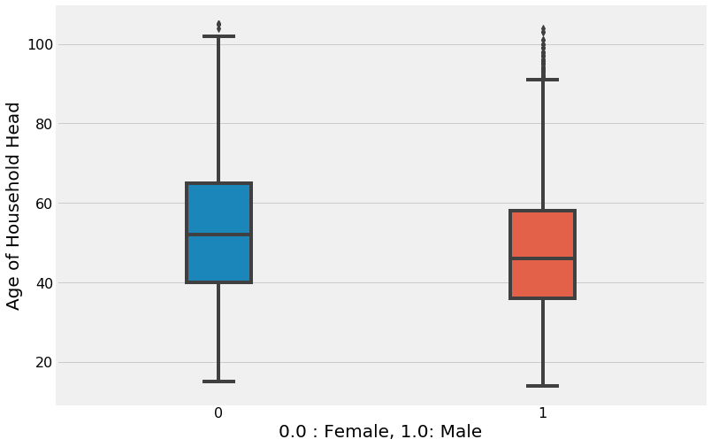

```python
fig, ax = plt.subplots()
fig.set_size_inches(11.7, 8.27)
sns.boxplot(x=data["head_male"], y=data['head_age'], width=0.2, ax=ax)
plt.ylabel("Age of Household Head")
plt.xlabel("0.0 : Female, 1.0: Male");
```

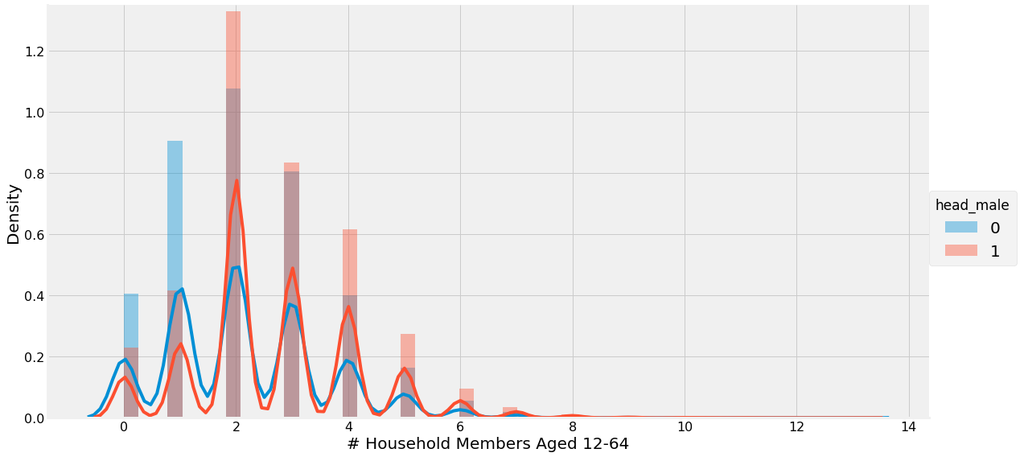

```python
g = sns.FacetGrid(data, hue="head_male", size=8, aspect=2)
g = g.map(sns.distplot, "age12_64").add_legend()
plt.ylabel("Density")
plt.xlabel("# Household Members Aged 12-64")
plt.ylim((0,1.35));
```

### c.

63.5% of households in the dataset are in urban settings. 36.5% of households in the dataset are in rural settings.

The percentage of emale headed households is higher in urban settings (18.3%) compared to rural settings (7.8%)

```python
def encode_urban(val):
    urban = list(range(1,4))
    if val in urban:
        return 1
    else:
        return 0
data['urban'] = data['loc_size'].apply(lambda x: encode_urban(x))
```

```python
data['urban'].value_counts()/data.shape[0]
```

```
1    0.63542
0    0.36458
Name: urban, dtype: float64
```

```python
data[data['head_male'] == 0.0]['urban'].value_counts()/data.shape[0]
```

```
1    0.183314
0    0.078281
Name: urban, dtype: float64
```

### d.

When inspecting the regression outputs below, we find that every bivariate regressions returns a statistically significant difference. Now, the coefficients are quite small, that is why we may not be able to see the differences via exploratory plots.

There are significant differences in households headed by men and women.

```python
def bivariate_regressions(data, treatment_col, y_col):
    treatment = data[treatment_col].values
    X = sm.add_constant(treatment)
    y = data[y_col].values
    model = sm.OLS(y, X, missing='drop')
    results = model.fit()
    print(f"Here are the results of regressing {y_col} on {treatment_col}: ")
    print()
    print(results.summary())
    print()

for y in ["head_age","head_college","tot_members","men", "women", "age12_64",
          "workers", "urban"]:
    bivariate_regressions(data, "head_male", y)
```

```
Here are the results of regressing head_age on head_male:

                            OLS Regression Results
==============================================================================
Dep. Variable:                      y   R-squared:                       0.019
Model:                            OLS   Adj. R-squared:                  0.019
Method:                 Least Squares   F-statistic:                     1345.
Date:                Wed, 24 Jan 2018   Prob (F-statistic):          9.45e-292
Time:                        16:05:28   Log-Likelihood:            -2.9399e+05
No. Observations:               70311   AIC:                         5.880e+05
Df Residuals:                   70309   BIC:                         5.880e+05
Df Model:                           1
Covariance Type:            nonrobust
==============================================================================
                 coef    std err          t      P>|t|      [0.025      0.975]
------------------------------------------------------------------------------
const         52.6466      0.117    450.819      0.000      52.418      52.875
x1            -4.9846      0.136    -36.678      0.000      -5.251      -4.718
==============================================================================
Omnibus:                     2606.288   Durbin-Watson:                   1.800
Prob(Omnibus):                  0.000   Jarque-Bera (JB):             2285.726
Skew:                           0.379   Prob(JB):                         0.00
Kurtosis:                       2.547   Cond. No.                         3.68
==============================================================================

Warnings:
[1] Standard Errors assume that the covariance matrix of the errors is correctly specified.

Here are the results of regressing head_college on head_male:

                            OLS Regression Results
==============================================================================
Dep. Variable:                      y   R-squared:                       0.001
Model:                            OLS   Adj. R-squared:                  0.001
Method:                 Least Squares   F-statistic:                     37.04
Date:                Wed, 24 Jan 2018   Prob (F-statistic):           1.17e-09
Time:                        16:05:28   Log-Likelihood:                -23666.
No. Observations:               64923   AIC:                         4.734e+04
Df Residuals:                   64921   BIC:                         4.735e+04
Df Model:                           1
```

[output cut: 168 more lines]

```
Covariance Type:            nonrobust
==============================================================================
                 coef    std err          t      P>|t|      [0.025      0.975]
------------------------------------------------------------------------------
const          0.7008      0.004    198.099      0.000       0.694       0.708
x1            -0.0885      0.004    -21.494      0.000      -0.097      -0.080
==============================================================================
Omnibus:                     3170.580   Durbin-Watson:                   0.017
Prob(Omnibus):                  0.000   Jarque-Bera (JB):            11728.199
Skew:                          -0.556   Prob(JB):                         0.00
Kurtosis:                       1.337   Cond. No.                         3.68
==============================================================================

Warnings:
[1] Standard Errors assume that the covariance matrix of the errors is correctly specified.
```

### e.

Yes, since we have statistically significance in every bivariate regression, we can say that the naive estimator is biased. Furthermore, all of the features tested in the bivariate regression should be included in the multivariate regression formulation in order to control for their effects.

### f.

```python
data["men_share"] = data['men']/data['tot_members']
```

```python
features = ["head_male", "head_college", "urban", "men_share"]

X = sm.add_constant(data[features].values)
y = data['job_earnings'].values
model = sm.OLS(y, X, missing='drop')
results = model.fit()
print(results.summary())
```

```
                            OLS Regression Results
==============================================================================
Dep. Variable:                      y   R-squared:                       0.117
Model:                            OLS   Adj. R-squared:                  0.117
Method:                 Least Squares   F-statistic:                     2148.
Date:                Wed, 24 Jan 2018   Prob (F-statistic):               0.00
Time:                        16:05:28   Log-Likelihood:            -7.6548e+05
No. Observations:               64923   AIC:                         1.531e+06
Df Residuals:                   64918   BIC:                         1.531e+06
Df Model:                           4
Covariance Type:            nonrobust
==============================================================================
                 coef    std err          t      P>|t|      [0.025      0.975]
------------------------------------------------------------------------------
const       9747.0951    360.706     27.022      0.000    9040.110    1.05e+04
x1          5799.6153    323.056     17.952      0.000    5166.426    6432.805
x2          2.753e+04    368.119     74.788      0.000    2.68e+04    2.83e+04
x3          9284.9952    270.360     34.343      0.000    8755.090    9814.901
x4           341.0096    573.422      0.595      0.552    -782.899    1464.918
==============================================================================
Omnibus:                   124628.681   Durbin-Watson:                   1.825
Prob(Omnibus):                  0.000   Jarque-Bera (JB):       1509237078.694
Skew:                          14.260   Prob(JB):                         0.00
Kurtosis:                     749.394   Cond. No.                         7.60
==============================================================================

Warnings:
[1] Standard Errors assume that the covariance matrix of the errors is correctly specified.
```

### g.

The average treatment effect is $\$5799.6153$.

This ATE is about $\$42.7$ greater than our naive estimate - as such, it is different to the naive estimate

An interesting finding is that the share of men in a household is not statistically significant with regards to job earnings of a household. This is interesting as our analysis shows that there is a difference between houeholds headed by men over women. However, it seems that other than having a male head of house (1 man), additional men do not contribute to wealth earnings.

```python
average_treatment_effect = results.params[1]
average_treatment_effect
```

```
5799.6153393454952
```

```python
naive_estimate - average_treatment_effect
```

```
-42.795026845495158
```

# Question 3

### a.

The naive estimate is $\$5756.822265625$

```python
data = pd.read_stata("Randomburg.dta")
data.head()
```

|  | household_id | job_earnings | head_male | head_age | tot_members | age12_64 | workers | head_college | rural |
| --- | --- | --- | --- | --- | --- | --- | --- | --- | --- |
| 0 | 1.801747e+09 | 0.000000 | 1.0 | 59.0 | 8.0 | 4.0 | 5.0 | 0.0 | 1.0 |
| 1 | 1.700536e+09 | 9880.429688 | 0.0 | 34.0 | 11.0 | 5.0 | 4.0 | 1.0 | 1.0 |
| 2 | 1.606071e+09 | 5869.549805 | 0.0 | 55.0 | 12.0 | 4.0 | 7.0 | 1.0 | 1.0 |
| 3 | 1.603798e+09 | 61770.441406 | 1.0 | 69.0 | 9.0 | 5.0 | 4.0 | 0.0 | 1.0 |
| 4 | 7.621170e+08 | 10736.299805 | 1.0 | 39.0 | 7.0 | 4.0 | 3.0 | 0.0 | 1.0 |

```python
#Mean Job Earnings of Male Headed Households only
male_earnings = data[data['head_male'] == 1]['job_earnings'].mean()
male_earnings
```

```
24621.755859375
```

```python
#Mean Job Earnings of Female Headed Households only
female_earnings = data[data['head_male'] == 0]['job_earnings'].mean()
female_earnings
```

```
18864.93359375
```

```python
naive_estimate = male_earnings - female_earnings
naive_estimate
```

```
5756.822265625
```

### b.

None of the bivariate regressions were statistically significant, as such, households headed by men and women are similar.

```python
for y in ["head_age", "tot_members", "age12_64",
          "workers", "head_college", "rural"]:
    bivariate_regressions(data, "head_male", y)
```

```
Here are the results of regressing head_age on head_male:

                            OLS Regression Results
==============================================================================
Dep. Variable:                      y   R-squared:                       0.000
Model:                            OLS   Adj. R-squared:                  0.000
Method:                 Least Squares   F-statistic:                     2.090
Date:                Wed, 24 Jan 2018   Prob (F-statistic):              0.148
Time:                        16:05:29   Log-Likelihood:            -2.9101e+05
No. Observations:               70311   AIC:                         5.820e+05
Df Residuals:                   70309   BIC:                         5.820e+05
Df Model:                           1
Covariance Type:            nonrobust
==============================================================================
                 coef    std err          t      P>|t|      [0.025      0.975]
------------------------------------------------------------------------------
const         48.7592      0.112    435.654      0.000      48.540      48.979
x1             0.1883      0.130      1.446      0.148      -0.067       0.444
==============================================================================
Omnibus:                      585.310   Durbin-Watson:                   1.998
Prob(Omnibus):                  0.000   Jarque-Bera (JB):              532.212
Skew:                           0.172   Prob(JB):                    2.70e-116
Kurtosis:                       2.749   Cond. No.                         3.68
==============================================================================

Warnings:
[1] Standard Errors assume that the covariance matrix of the errors is correctly specified.

Here are the results of regressing tot_members on head_male:

                            OLS Regression Results
==============================================================================
Dep. Variable:                      y   R-squared:                       0.000
Model:                            OLS   Adj. R-squared:                 -0.000
Method:                 Least Squares   F-statistic:                   0.05890
Date:                Wed, 24 Jan 2018   Prob (F-statistic):              0.808
Time:                        16:05:29   Log-Likelihood:            -1.4175e+05
No. Observations:               70311   AIC:                         2.835e+05
Df Residuals:                   70309   BIC:                         2.835e+05
Df Model:                           1
```

[output cut: 112 more lines]

```
Covariance Type:            nonrobust
==============================================================================
                 coef    std err          t      P>|t|      [0.025      0.975]
------------------------------------------------------------------------------
const          0.4975      0.004    134.948      0.000       0.490       0.505
x1             0.0033      0.004      0.779      0.436      -0.005       0.012
==============================================================================
Omnibus:                        0.000   Durbin-Watson:                   0.000
Prob(Omnibus):                  1.000   Jarque-Bera (JB):            11718.096
Skew:                           0.000   Prob(JB):                         0.00
Kurtosis:                       1.000   Cond. No.                         3.68
==============================================================================

Warnings:
[1] Standard Errors assume that the covariance matrix of the errors is correctly specified.
```

### c.

Since all of the bivariate regressions were statistically insignificant, the naive estimator is unbiased. That is to say, in this case, we do not have a selection problem.

### d.

```python
features = data.columns[2:]

X = sm.add_constant(data[features].values)
y = data['job_earnings'].values
model = sm.OLS(y, X, missing='drop')
results = model.fit()
print(results.summary())
```

```
                            OLS Regression Results
==============================================================================
Dep. Variable:                      y   R-squared:                       0.006
Model:                            OLS   Adj. R-squared:                  0.006
Method:                 Least Squares   F-statistic:                     59.45
Date:                Wed, 24 Jan 2018   Prob (F-statistic):           1.48e-85
Time:                        16:05:29   Log-Likelihood:            -8.3138e+05
No. Observations:               70311   AIC:                         1.663e+06
Df Residuals:                   70303   BIC:                         1.663e+06
Df Model:                           7
Covariance Type:            nonrobust
==============================================================================
                 coef    std err          t      P>|t|      [0.025      0.975]
------------------------------------------------------------------------------
const       1.816e+04   1048.932     17.316      0.000    1.61e+04    2.02e+04
x1          5757.3496    283.533     20.306      0.000    5201.626    6313.073
x2            -6.4943      8.209     -0.791      0.429     -22.585       9.596
x3            61.1657     68.583      0.892      0.372     -73.258     195.589
x4            36.2460     85.370      0.425      0.671    -131.079     203.571
x5             2.0618    122.738      0.017      0.987    -238.504     242.627
x6           239.7231    249.220      0.962      0.336    -248.748     728.194
x7           291.1172    249.216      1.168      0.243    -197.346     779.580
==============================================================================
Omnibus:                   128572.415   Durbin-Watson:                   1.997
Prob(Omnibus):                  0.000   Jarque-Bera (JB):       1104344127.773
Skew:                          12.842   Prob(JB):                         0.00
Kurtosis:                     616.431   Cond. No.                         443.
==============================================================================

Warnings:
[1] Standard Errors assume that the covariance matrix of the errors is correctly specified.
```

## e.

The treatment effect is $\$5,757.35$. This is a difference of $-\$0.53$ - that is to say the treatment effect and the naive estimate are almost identical. This is consistent with our findings that we do not have a selection problem with this dataset. As such, the naive estimate **should** be similar to the calculated treatment effect.

```python
treatment_effect = results.params[1]
naive_estimate - treatment_effect
```

```
-0.52732227120031894
```